# 01_Sales

```python
import pyodbc
import numpy as np
import pandas as pd
import matplotlib.pyplot as plt
from matplotlib.ticker import FuncFormatter
```

sql data import

```python
sql_conn = pyodbc.connect(
    "DRIVER={ODBC Driver 18 for SQL Server};"
    "SERVER=localhost\\SQLEXPRESS;"
    "DATABASE=Excel;"
    "UID=AS;"
    "PWD=Sur7aj6@;"
    "Encrypt=yes;"
    "TrustServerCertificate=yes;"
)

print("✅ SQL Server Connected Successfully!")
```

```
✅ SQL Server Connected Successfully!
```

```python
df = pd.read_sql("SELECT * FROM Sales_Data", sql_conn)
```

```
C:\Users\Anish Kumar\AppData\Local\Temp\ipykernel_23596\470251366.py:1: UserWarning: pandas only supports SQLAlchemy connectable (engine/connection) or database string URI or sqlite3 DBAPI2 connection. Other DBAPI2 objects are not tested. Please consider using SQLAlchemy.
  df = pd.read_sql("SELECT * FROM Sales_Data", sql_conn)
```

```python
df.head(5)
```

|  | OrderID | OrderDate | Customer | City | Product | Category | Quantity | UnitPrice | Sales | Salesperson | Region | PaymentMode |
| --- | --- | --- | --- | --- | --- | --- | --- | --- | --- | --- | --- | --- |
| 0 | ORD10001 | 2025-04-19 | Customer_001 | Delhi | Printer | Office | 7 | 8500.0 | 59500.0 | Anjali | North | Cash |
| 1 | ORD10002 | 2025-03-16 | Customer_002 | Bangalore | Keyboard | Accessories | 4 | 1800.0 | 7200.0 | Vikas | South | Credit Card |
| 2 | ORD10003 | 2025-05-26 | Customer_003 | Delhi | Chair | Furniture | 7 | 7000.0 | 49000.0 | Neha | North | Debit Card |
| 3 | ORD10004 | 2025-05-08 | Customer_004 | Delhi | Mouse | Accessories | 6 | 900.0 | 5400.0 | Priya | North | Net Banking |
| 4 | ORD10005 | 2025-02-11 | Customer_005 | Bangalore | Printer | Office | 2 | 8500.0 | 17000.0 | Vikas | South | Cash |

```python
df.tail(5)
```

|  | OrderID | OrderDate | Customer | City | Product | Category | Quantity | UnitPrice | Sales | Salesperson | Region | PaymentMode |
| --- | --- | --- | --- | --- | --- | --- | --- | --- | --- | --- | --- | --- |
| 495 | ORD10496 | 2025-12-01 | Customer_496 | Noida | Laptop | Electronics | 6 | 55000.0 | 330000.0 | Neha | North | Debit Card |
| 496 | ORD10497 | 2026-02-22 | Customer_497 | Gurgaon | Printer | Office | 4 | 8500.0 | 34000.0 | Priya | North | Cash |
| 497 | ORD10498 | 2025-10-22 | Customer_498 | Delhi | Printer | Office | 2 | 8500.0 | 17000.0 | Pooja | North | Cash |
| 498 | ORD10499 | 2026-01-06 | Customer_499 | Pune | Desk | Furniture | 2 | 11000.0 | 22000.0 | Vikas | West | Credit Card |
| 499 | ORD10500 | 2025-07-05 | Customer_500 | Noida | Headphones | Accessories | 5 | 2500.0 | 12500.0 | Pooja | North | UPI |

```python
df.info()
```

```
<class 'pandas.DataFrame'>
RangeIndex: 500 entries, 0 to 499
Data columns (total 12 columns):
 #   Column       Non-Null Count  Dtype
---  ------       --------------  -----
 0   OrderID      500 non-null    str
 1   OrderDate    500 non-null    object
 2   Customer     500 non-null    str
 3   City         500 non-null    str
 4   Product      500 non-null    str
 5   Category     500 non-null    str
 6   Quantity     500 non-null    int64
 7   UnitPrice    500 non-null    float64
 8   Sales        500 non-null    float64
 9   Salesperson  500 non-null    str
 10  Region       500 non-null    str
 11  PaymentMode  500 non-null    str
dtypes: float64(2), int64(1), object(1), str(8)
memory usage: 47.0+ KB
```

```python
df.describe()
```

|  | Quantity | UnitPrice | Sales |
| --- | --- | --- | --- |
| count | 500.000000 | 500.000000 | 500.000000 |
| mean | 4.098000 | 14667.000000 | 57241.000000 |
| std | 2.031909 | 16466.019269 | 75252.935542 |
| min | 1.000000 | 900.000000 | 900.000000 |
| 25% | 2.000000 | 2500.000000 | 9000.000000 |
| 50% | 4.000000 | 8500.000000 | 35000.000000 |
| 75% | 6.000000 | 18000.000000 | 66000.000000 |
| max | 7.000000 | 55000.000000 | 385000.000000 |

```python
df.dtypes
```

```
OrderID            str
OrderDate       object
Customer           str
City               str
Product            str
Category           str
Quantity         int64
UnitPrice      float64
Sales          float64
Salesperson        str
Region             str
PaymentMode        str
dtype: object
```

```python
df.columns
```

```
Index(['OrderID', 'OrderDate', 'Customer', 'City', 'Product', 'Category',
       'Quantity', 'UnitPrice', 'Sales', 'Salesperson', 'Region',
       'PaymentMode'],
      dtype='str')
```

```python
np.random.seed(42)
first_names = [
    "Aarav", "Aditi", "Aditya", "Akash", "Aman", "Amit", "Ananya", "Anjali", "Ankit", "Arjun",
    "Ashish", "Ayush", "Deepak", "Divya", "Gaurav", "Isha", "Karan", "Kavita", "Kunal", "Manish",
    "Meera", "Mohit", "Neha", "Nikhil", "Nisha", "Pankaj", "Pooja", "Prakash", "Priya", "Rahul",
    "Raj", "Rajat", "Rakesh", "Ravi", "Riya", "Rohit", "Sachin", "Sakshi", "Sameer", "Sandeep",
    "Sanjay", "Shivam", "Shreya", "Simran", "Sonali", "Sourav", "Sunil", "Swati", "Tarun", "Vikas",
    "Vikram", "Vineet", "Vishal", "Yash", "Yogesh", "Varun", "Komal", "Muskan", "Naveen", "Nitin",
    "Pawan", "Pranav", "Raghav", "Rajat", "Ramesh", "Rani", "Rashmi", "Reena", "Renu", "Richa",
    "Ritu", "Riya", "Rupali", "Sahil", "Sakshi", "Salman", "Samir", "Sana", "Sanjana", "Sarika",
    "Seema", "Shalini", "Shankar", "Shikha", "Shruti", "Siddharth", "Sneha", "Sonia", "Srishti", "Sumit",
    "Suraj", "Suresh", "Tanisha", "Tanya", "Tanu", "Tushar", "Uday", "Uma", "Vaibhav", "Varsha",
    "Vedant", "Veer", "Vijay", "Vinay", "Vivek", "Waseem", "Zaid", "Zoya", "Abhay", "Abhishek",
    "Adarsh", "Ajay", "Ajit", "Alok", "Amar", "Amisha", "Amol", "Anand", "Anil", "Anirudh",
    "Anisha", "Ansh", "Anshu", "Antara", "Apoorva", "Archana", "Arnav", "Arpita", "Aryan", "Ashok",
    "Avinash", "Bharat", "Bhavna", "Bhavesh", "Bhumika", "Chetan", "Chirag", "Darshan", "Daya", "Dev",
    "Devansh", "Dhanush", "Diksha", "Dinesh", "Ekta", "Farhan", "Faisal", "Garima", "Geeta", "Harish",
    "Harsh", "Harsha", "Himanshu", "Hina", "Inder", "Ishaan", "Jagdish", "Jatin", "Jaya", "Jayant",
    "Jeevan", "Jyoti", "Kabir", "Kajal", "Kamal", "Kanika", "Kartik", "Kashish", "Kavya", "Khushi",
    "Kirti", "Krishna", "Kriti", "Kunal", "Lakshay", "Lalit", "Lavanya", "Lokesh", "Madhav", "Madhu",
    "Mahesh", "Mahi", "Malini", "Mamta", "Mansi", "Mayank", "Meena", "Mihir", "Milan", "Mira",
    "Mohan", "Monika", "Mukesh", "Naina", "Naksh", "Namita", "Nandini", "Naresh", "Navin", "Nayan",
    "Neel", "Neelam", "Neeraj", "Nidhi", "Nikita", "Nilesh", "Nirmal", "Nitin", "Nivedita", "Ojas",
    "Om", "Palak", "Parag", "Pari", "Parth", "Payal", "Piyush", "Preeti", "Pritam", "Purva",
    "Rachit", "Radha", "Ragini", "Rajeev", "Rajesh", "Rajiv", "Ranjit", "Rashid", "Ravi", "Rekha",
    "Ritesh", "Rohini", "Roshan", "Ruchi", "Sachin", "Sagar", "Saloni", "Sameera", "Sanjay", "Santosh",
    "Saroj", "Saurabh", "Shahid", "Shailesh", "Shanaya", "Shashank", "Shekhar", "Shivani", "Shubham", "Shweta",
    "Siddhi", "Smita", "Sonal", "Sonam", "Sourabh", "Sparsh", "Suman", "Sunita", "Surabhi", "Sushant",
    "Sushil", "Swara", "Tanuja", "Tejas", "Tina", "Trisha", "Ujjwal", "Umesh", "Upasana", "Utkarsh",
    "Vandana", "Varun", "Vasu", "Vatsal", "Vidhi", "Vidya", "Vikas", "Vimal", "Vineeta", "Vipul",
    "Vishakha", "Vishnu", "Yamini", "Yatin", "Yuvraj", "Zara", "Ayesha", "Bilal", "Danish", "Imran",
    "Irfan", "Javed", "Kashif", "Nadeem", "Nazia", "Rizwan", "Saif", "Shabnam", "Shadab", "Shahnawaz",
    "Shoaib", "Sohail", "Tabassum", "Wasim", "Aaliya", "Aamir", "Afreen", "Alisha", "Armaan", "Asif",
    "Azhar", "Faizan", "Hammad", "Haseeb", "Humaira", "Kiran", "Lubna", "Mariam", "Mehreen", "Nusrat",
    "Rafia", "Rehan", "Rubina", "Saba", "Sabina", "Sadia", "Sahil", "Samina", "Shakir", "Shazia",
    "Aakash", "Aarohi", "Aastha", "Aayush", "Aditi", "Aishwarya", "Akansha", "Akshat", "Akshara", "Amrita",
    "Apoorv", "Aradhya", "Bharti", "Charu", "Damini", "Esha", "Gauri", "Ishita", "Jhanvi", "Juhi",
    "Kanchan", "Karishma", "Kriti", "Madhuri", "Mahima", "Manisha", "Manya", "Mitali", "Nandita", "Navya",
    "Niharika", "Pallavi", "Poonam", "Pragya", "Preeti", "Radhika", "Rajni", "Rashika", "Raveena", "Riddhi",
    "Roshni", "Sakina", "Salma", "Sapna", "Shanvi", "Shivangi", "Shreya", "Sonali", "Tanvi", "Tara",
    "Tulika", "Vaishali", "Vani", "Vasudha", "Veda", "Vidushi", "Yashika", "Zeenat", "Aarti", "Aarav",
    "Abhinav", "Advik", "Ahan", "Akhil", "Anmol", "Arpit", "Atharv", "Dhruv", "Harshit", "Hrithik",
    "Keshav", "Krish", "Laksh", "Manav", "Mudit", "Naman", "Nakul", "Parveen", "Prateek", "Raghav",
    "Ranveer", "Rituraj", "Shivam", "Shrey", "Tanish", "Tanu", "Utsav", "Vansh", "Varad", "Vivaan",
    "Yuvika", "Zubin", "Aarush", "Abeer", "Adit", "Aditiya", "Anshul", "Avni", "Bhavya", "Dhara",
    "Harshita", "Ishika", "Janvi", "Kashvi", "Kiana", "Myra", "Navneet", "Nitya", "Pari", "Prisha",
    "Rhea", "Saanvi", "Samaira", "Shanaya", "Siya", "Tia", "Vanya", "Zoya", "Ayesha", "Diya",
    "Ishani", "Mahi", "Mishka", "Ruhani", "Suhani", "Anvi", "Aarna", "Kiara", "Aadhya", "Aaradhya",
    "Aahana", "Anvika", "Charvi", "Devika", "Ira", "Jiya", "Kaira", "Navya", "Nyla", "Pranavi",
    "Riddhima", "Samaira", "Sharanya", "Shivanya", "Suhana", "Tanishka", "Vamika", "Vritika", "Yashvi", "Ziva"
]

last_names = [
    "Sharma", "Verma", "Kumar", "Singh", "Gupta",
    "Yadav", "Mishra", "Pandey", "Tiwari", "Jha",
    "Chauhan", "Rajput", "Thakur", "Sinha", "Prasad",
    "Agarwal", "Bansal", "Jain", "Sahu", "Saxena",
    "Srivastava", "Tripathi", "Dubey", "Dwivedi", "Shukla",
    "Pathak", "Joshi", "Mehta", "Shah", "Patel",
    "Desai", "Rao", "Reddy", "Naidu", "Iyer",
    "Nair", "Menon", "Pillai", "Kapoor", "Malhotra",
    "Arora", "Khanna", "Chopra", "Bhatia", "Sethi",
    "Ahuja", "Chawla", "Goyal", "Mittal", "Goel",
    "Kohli", "Bhardwaj", "Bhatt", "Rawat", "Negi",
    "Bisht", "Rana", "Dixit", "Prajapati", "Maurya",
    "Kushwaha", "Mandal", "Das", "Dutta", "Ghosh",
    "Bose", "Banerjee", "Mukherjee", "Chatterjee", "Sen",
    "Roy", "Pal", "Sarkar", "Nath", "Dey",
    "Soni", "Gupta", "Khatri", "Wadhwa", "Tandon",
    "Bajaj", "Singhal", "Aggarwal", "Puri", "Batra",
    "Khurana", "Anand", "Vohra", "Sachdeva", "Luthra",
    "Madan", "Bedi", "Talwar", "Oberoi", "Handa",
    "Mathur", "Kulkarni", "Deshmukh", "Patil", "More"
]
df["Customer"] = (
    np.random.choice(first_names, size=len(df)) + " " + np.random.choice(last_names, size=len(df))
)
```

```python
df["PaymentMode"].unique()
```

```
<StringArray>
['Cash', 'Credit Card', 'Debit Card', 'Net Banking', 'UPI']
Length: 5, dtype: str
```

```python
df["Region"].unique()
```

```
<StringArray>
['North', 'South', 'West', 'East']
Length: 4, dtype: str
```

```python
df["OrderDate"] = pd.to_datetime(df["OrderDate"],format="mixed").dt.strftime("%d/%m/%Y")
```

```python
df.head(5)
```

|  | OrderID | OrderDate | Customer | City | Product | Category | Quantity | UnitPrice | Sales | Salesperson | Region | PaymentMode |
| --- | --- | --- | --- | --- | --- | --- | --- | --- | --- | --- | --- | --- |
| 0 | ORD10001 | 19/04/2025 | Vijay Patil | Delhi | Printer | Office | 7 | 8500.0 | 59500.0 | Anjali | North | Cash |
| 1 | ORD10002 | 16/03/2025 | Myra Goel | Bangalore | Keyboard | Accessories | 4 | 1800.0 | 7200.0 | Vikas | South | Credit Card |
| 2 | ORD10003 | 26/05/2025 | Jhanvi Shukla | Delhi | Chair | Furniture | 7 | 7000.0 | 49000.0 | Neha | North | Debit Card |
| 3 | ORD10004 | 08/05/2025 | Vandana Dwivedi | Delhi | Mouse | Accessories | 6 | 900.0 | 5400.0 | Priya | North | Net Banking |
| 4 | ORD10005 | 11/02/2025 | Zaid Thakur | Bangalore | Printer | Office | 2 | 8500.0 | 17000.0 | Vikas | South | Cash |

North ka multiple columns data

```python
North = df[df["Region"] == "North"][[
    "OrderID",
    "OrderDate",
    "Customer",
    "City",
    "Product",
    "Category",
    "Quantity",
    "UnitPrice",
    "Sales",
    "Salesperson",
    "Region",
    "PaymentMode"
]]
North
```

|  | OrderID | OrderDate | Customer | City | Product | Category | Quantity | UnitPrice | Sales | Salesperson | Region | PaymentMode |
| --- | --- | --- | --- | --- | --- | --- | --- | --- | --- | --- | --- | --- |
| 0 | ORD10001 | 19/04/2025 | Vijay Patil | Delhi | Printer | Office | 7 | 8500.0 | 59500.0 | Anjali | North | Cash |
| 2 | ORD10003 | 26/05/2025 | Jhanvi Shukla | Delhi | Chair | Furniture | 7 | 7000.0 | 49000.0 | Neha | North | Debit Card |
| 3 | ORD10004 | 08/05/2025 | Vandana Dwivedi | Delhi | Mouse | Accessories | 6 | 900.0 | 5400.0 | Priya | North | Net Banking |
| 7 | ORD10008 | 03/02/2025 | Meera Rana | Delhi | Printer | Office | 4 | 8500.0 | 34000.0 | Vikas | North | Debit Card |
| 10 | ORD10011 | 13/01/2026 | Kaira Saxena | Gurgaon | Keyboard | Accessories | 1 | 1800.0 | 1800.0 | Priya | North | Credit Card |
| ... | ... | ... | ... | ... | ... | ... | ... | ... | ... | ... | ... | ... |
| 493 | ORD10494 | 27/05/2026 | Shashank Pandey | Delhi | Printer | Office | 6 | 8500.0 | 51000.0 | Neha | North | Debit Card |
| 495 | ORD10496 | 01/12/2025 | Sameer Singh | Noida | Laptop | Electronics | 6 | 55000.0 | 330000.0 | Neha | North | Debit Card |
| 496 | ORD10497 | 22/02/2026 | Vamika Bisht | Gurgaon | Printer | Office | 4 | 8500.0 | 34000.0 | Priya | North | Cash |
| 497 | ORD10498 | 22/10/2025 | Khushi Shukla | Delhi | Printer | Office | 2 | 8500.0 | 17000.0 | Pooja | North | Cash |
| 499 | ORD10500 | 05/07/2025 | Pankaj Mathur | Noida | Headphones | Accessories | 5 | 2500.0 | 12500.0 | Pooja | North | UPI |

196 rows × 12 columns

```python
df[df["Region"] == "North"][["Customer","Product", "Quantity", "UnitPrice", "Sales"]]
```

|  | Customer | Product | Quantity | UnitPrice | Sales |
| --- | --- | --- | --- | --- | --- |
| 0 | Vijay Patil | Printer | 7 | 8500.0 | 59500.0 |
| 2 | Jhanvi Shukla | Chair | 7 | 7000.0 | 49000.0 |
| 3 | Vandana Dwivedi | Mouse | 6 | 900.0 | 5400.0 |
| 7 | Meera Rana | Printer | 4 | 8500.0 | 34000.0 |
| 10 | Kaira Saxena | Keyboard | 1 | 1800.0 | 1800.0 |
| ... | ... | ... | ... | ... | ... |
| 493 | Shashank Pandey | Printer | 6 | 8500.0 | 51000.0 |
| 495 | Sameer Singh | Laptop | 6 | 55000.0 | 330000.0 |
| 496 | Vamika Bisht | Printer | 4 | 8500.0 | 34000.0 |
| 497 | Khushi Shukla | Printer | 2 | 8500.0 | 17000.0 |
| 499 | Pankaj Mathur | Headphones | 5 | 2500.0 | 12500.0 |

196 rows × 5 columns

## Pandas Question

Q1. Calculate the total Sales.

```python
total_sales = df["Sales"].sum()
print("Total Sales:", total_sales)
```

```
Total Sales: 28620500.0
```

Q2. Calculate the average Sales.

```python
avg_sales = df["Sales"].mean().round(2)

print("Avg Sales:", avg_sales)
```

```
Avg Sales: 57241.0
```

Q3. Find the order with the maximum Sales.

```python
max_Sales = df["Sales"].max()
print("Max Sales", max_Sales)
```

```
Max Sales 385000.0
```

Q4. Find the order with the minimum Sales.

```python
min_Sales = df["Sales"].min()
print("Minimum Sales", min_Sales)
```

```
Minimum Sales 900.0
```

Q5. Find the top 10 orders with the highest Sales.

```python
Highest_Sales = df.nlargest(10, "Sales")
Highest_Sales
```

|  | OrderID | OrderDate | Customer | City | Product | Category | Quantity | UnitPrice | Sales | Salesperson | Region | PaymentMode |
| --- | --- | --- | --- | --- | --- | --- | --- | --- | --- | --- | --- | --- |
| 51 | ORD10052 | 03/06/2025 | Yogesh Patil | Noida | Laptop | Electronics | 7 | 55000.0 | 385000.0 | Amit | North | Cash |
| 78 | ORD10079 | 14/11/2025 | Riya Sharma | Pune | Laptop | Electronics | 7 | 55000.0 | 385000.0 | Amit | West | Net Banking |
| 110 | ORD10111 | 05/05/2026 | Nitin Oberoi | Gurgaon | Laptop | Electronics | 7 | 55000.0 | 385000.0 | Neha | North | Debit Card |
| 183 | ORD10184 | 06/11/2025 | Raghav Singhal | Pune | Laptop | Electronics | 7 | 55000.0 | 385000.0 | Rahul | West | Credit Card |
| 268 | ORD10269 | 02/03/2026 | Ajit Sethi | Pune | Laptop | Electronics | 7 | 55000.0 | 385000.0 | Priya | West | UPI |
| 294 | ORD10295 | 21/08/2025 | Nadeem Gupta | Noida | Laptop | Electronics | 7 | 55000.0 | 385000.0 | Neha | North | Debit Card |
| 435 | ORD10436 | 20/02/2026 | Faisal Gupta | Mumbai | Laptop | Electronics | 7 | 55000.0 | 385000.0 | Priya | West | Net Banking |
| 490 | ORD10491 | 24/02/2026 | Utsav Handa | Delhi | Laptop | Electronics | 7 | 55000.0 | 385000.0 | Amit | North | Debit Card |
| 114 | ORD10115 | 01/06/2025 | Vishal More | Mumbai | Laptop | Electronics | 6 | 55000.0 | 330000.0 | Rohit | West | Debit Card |
| 156 | ORD10157 | 03/01/2025 | Vaibhav Iyer | Mumbai | Laptop | Electronics | 6 | 55000.0 | 330000.0 | Rahul | West | Net Banking |

Q6. Find the bottom 10 orders with the lowest Sales.

```python
lower_Sales = df.nsmallest(10, "Sales")
lower_Sales
```

|  | OrderID | OrderDate | Customer | City | Product | Category | Quantity | UnitPrice | Sales | Salesperson | Region | PaymentMode |
| --- | --- | --- | --- | --- | --- | --- | --- | --- | --- | --- | --- | --- |
| 186 | ORD10187 | 01/01/2026 | Saroj Dubey | Mumbai | Mouse | Accessories | 1 | 900.0 | 900.0 | Pooja | West | Credit Card |
| 386 | ORD10387 | 21/01/2026 | Radhika Prajapati | Patna | Mouse | Accessories | 1 | 900.0 | 900.0 | Anjali | East | Debit Card |
| 418 | ORD10419 | 13/08/2025 | Rekha Singh | Pune | Mouse | Accessories | 1 | 900.0 | 900.0 | Amit | West | UPI |
| 9 | ORD10010 | 02/06/2025 | Ansh Sethi | Pune | Mouse | Accessories | 2 | 900.0 | 1800.0 | Amit | West | UPI |
| 10 | ORD10011 | 13/01/2026 | Kaira Saxena | Gurgaon | Keyboard | Accessories | 1 | 1800.0 | 1800.0 | Priya | North | Credit Card |
| 15 | ORD10016 | 14/10/2025 | Salma Soni | Pune | Mouse | Accessories | 2 | 900.0 | 1800.0 | Anjali | West | Debit Card |
| 125 | ORD10126 | 15/12/2025 | Ramesh Agarwal | Gurgaon | Keyboard | Accessories | 1 | 1800.0 | 1800.0 | Neha | North | Credit Card |
| 130 | ORD10131 | 02/03/2026 | Aryan Rao | Kolkata | Keyboard | Accessories | 1 | 1800.0 | 1800.0 | Pooja | East | Credit Card |
| 167 | ORD10168 | 20/05/2025 | Avinash Mukherjee | Bangalore | Keyboard | Accessories | 1 | 1800.0 | 1800.0 | Anjali | South | Cash |
| 181 | ORD10182 | 07/08/2026 | Aahana Patil | Patna | Mouse | Accessories | 2 | 900.0 | 1800.0 | Rahul | East | Debit Card |

Q7. Calculate the total Quantity sold.

```python
Total_Quantity = df["Quantity"].sum()
print("Total Quantity:- ",Total_Quantity)
```

```
Total Quantity:-  2049
```

Q8. Calculate total Sales for each Product.

```python
product_sales = (
    df.groupby("Product", as_index=False)["Sales"].sum().sort_values("Sales", ascending=False)
)

product_sales
```

|  | Product | Sales |
| --- | --- | --- |
| 4 | Laptop | 12265000.0 |
| 5 | Mobile | 3960000.0 |
| 9 | Tablet | 3780000.0 |
| 1 | Desk | 2057000.0 |
| 6 | Monitor | 2028000.0 |
| 8 | Printer | 1972000.0 |
| 0 | Chair | 1449000.0 |
| 2 | Headphones | 565000.0 |
| 3 | Keyboard | 342000.0 |
| 7 | Mouse | 202500.0 |

Q9. Calculate total Quantity sold for each Product.

```python
product_quantity = df.groupby("Product", as_index=False)["Quantity"].sum().sort_values("Quantity", ascending=False)
product_quantity
```

|  | Product | Quantity |
| --- | --- | --- |
| 8 | Printer | 232 |
| 2 | Headphones | 226 |
| 7 | Mouse | 225 |
| 4 | Laptop | 223 |
| 9 | Tablet | 210 |
| 0 | Chair | 207 |
| 3 | Keyboard | 190 |
| 1 | Desk | 187 |
| 5 | Mobile | 180 |
| 6 | Monitor | 169 |

Q10. Which Product has the highest total Sales?

```python
Highest_Sales = df.groupby("Product")["Sales"].sum()
print("Product:", Highest_Sales.idxmax())
print("Sales:", Highest_Sales.max())
```

```
Product: Laptop
Sales: 12265000.0
```

Q13. Which Product has the highest Quantity sold?

```python
Highest_Quantity = df.groupby("Product")["Quantity"].sum()
print("Product:",Highest_Quantity.idxmax())
print("Quantity: ",Highest_Quantity.max())
```

```
Product: Printer
Quantity:  232
```

Q14. Calculate the average Sales for each Product.

```python
Avg_Product = df.groupby("Product")["Sales"].mean()
print("Avg Product", Avg_Product)
```

```
Avg Product Product
Chair          28411.764706
Desk           46750.000000
Headphones      9912.280702
Keyboard        7125.000000
Laptop        197822.580645
Mobile         96585.365854
Monitor        52000.000000
Mouse           4132.653061
Printer        35854.545455
Tablet         70000.000000
Name: Sales, dtype: float64
```

Q15. Calculate total Sales for each Category.

```python
Total_Category = df.groupby("Category")["Sales"].sum()
Total_Category
```

```
Category
Accessories     1109500.0
Electronics    22033000.0
Furniture       3506000.0
Office          1972000.0
Name: Sales, dtype: float64
```

Q16. Calculate total Quantity for each Category.

```python
Category_Quantity = df.groupby("Category")["Quantity"].sum()
Category_Quantity
```

```
Category
Accessories    641
Electronics    782
Furniture      394
Office         232
Name: Quantity, dtype: int64
```

Q17. Calculate average Sales for each Category.

```python
avg_category = df.groupby("Category")["Sales"].mean()
avg_category
```

```
Category
Accessories      7204.545455
Electronics    112413.265306
Furniture       36905.263158
Office          35854.545455
Name: Sales, dtype: float64
```

Q18. Find the highest-performing Category.

```python
Category_Sales = df.groupby("Category")["Sales"].sum()
print("Category:", Category_Sales.idxmax())
print("Total Sales:", Category_Sales.max())
```

```
Category: Electronics
Total Sales: 22033000.0
```

Q19. Calculate total Sales for each City.

```python
total_city = df.groupby("City")["Sales"].sum()
total_city
```

```
City
Bangalore    3257100.0
Delhi        3234200.0
Gurgaon      3402500.0
Kolkata      3174400.0
Mumbai       4404400.0
Noida        4256500.0
Patna        3279400.0
Pune         3612000.0
Name: Sales, dtype: float64
```

Q20. Calculate total Sales for each Region.

```python
Regin_By_Sales = df.groupby("Region")["Sales"].sum()
Regin_By_Sales
```

```
Region
East      6453800.0
North    10893200.0
South     3257100.0
West      8016400.0
Name: Sales, dtype: float64
```

Q21. Which City has the highest Sales?

```python
highest_Sales = df.groupby("City")["Sales"].sum()
print("City: ", highest_Sales.idxmax())
print("Sales: ", highest_Sales.max())
```

```
City:  Mumbai
Sales:  4404400.0
```

Q23. Calculate total Sales for each Salesperson.

```python
Total_Salesperson = df.groupby("Salesperson")["Sales"].sum()
Total_Salesperson
```

```
Salesperson
Amit      4968700.0
Anjali    2951200.0
Neha      4157200.0
Pooja     2021600.0
Priya     3241400.0
Rahul     4486800.0
Rohit     3565300.0
Vikas     3228300.0
Name: Sales, dtype: float64
```

Q27. Calculate the number of Orders for each Payment Mode using Pandas.

```python
Orders_By_Payment = df.groupby("PaymentMode")["OrderID"].nunique()
Orders_By_Payment
```

```
PaymentMode
Cash           100
Credit Card     85
Debit Card     117
Net Banking    107
UPI             91
Name: OrderID, dtype: int64
```

Q28. create a relationship between UnitPrice and Sales

```python
UnitPrice_Sales = df.groupby("UnitPrice")["Sales"].sum()
UnitPrice_Sales
```

```
UnitPrice
900.0        202500.0
1800.0       342000.0
2500.0       565000.0
7000.0      1449000.0
8500.0      1972000.0
11000.0     2057000.0
12000.0     2028000.0
18000.0     3780000.0
22000.0     3960000.0
55000.0    12265000.0
Name: Sales, dtype: float64
```

## Date

```python
df["OrderDate"] = pd.to_datetime(
    df["OrderDate"],
    format="%d/%m/%Y"
)
```

```python
df["OrderDate"].dtype
```

```
dtype('<M8[us]')
```

```python
df["Month"] = df["OrderDate"].dt.month_name()
```

28. calculate the total Sales for each month.

```python
Month_sales = df.groupby(
    "Month",
    observed=True
)["Sales"].sum()

Month_sales
```

```
Month
April        2406700.0
August       2500900.0
December     1607800.0
February     3407900.0
January      2463500.0
July         1882700.0
June         3447000.0
March        3425900.0
May          2990400.0
November     2074000.0
October      1630700.0
September     783000.0
Name: Sales, dtype: float64
```

## Numpy Question

1. Convert the Sales column into a NumPy array.

```python
sales_array = np.array(df["Sales"])
sales_array
```

[output not shown]

[output cut: 17 more lines]

```
        49000.,   3600., 110000.,  59500.,   4500.,  12000.,   8500.,
        17500.,  54000.,  17500.,   2700.,  84000.,  55000.,   5400.,
        55000.,  12600.,   4500.,  54000.,  54000.,    900.,  34000.,
        12600., 110000.,   2700.,  51000., 108000.,  54000.,  48000.,
         3600.,   9000., 132000.,   9000., 108000., 126000.,  17500.,
        36000., 385000.,  14000.,   6300.,   1800.,  49000.,  42500.,
        66000., 275000.,   5400.,  28000., 110000.,  10000., 110000.,
       110000.,   2500.,   6300.,  12500., 220000., 165000.,  14000.,
       126000.,  44000.,   7500., 154000.,  17500.,  34000., 220000.,
        90000.,  35000., 108000., 108000.,  18000.,  44000.,  12500.,
        44000.,  25500.,   7200.,  36000.,   5400.,  88000.,   7000.,
         3600.,  66000.,   2700.,  66000.,  12600.,  18000.,   1800.,
        33000.,   7000.,  15000.,  55000.,   5000.,   9000.,  22000.,
       385000.,   8500.,  42000.,  51000.,   2700., 330000.,  34000.,
        17000.,  22000.,  12500.])
```

2. Calculate total Sales using NumPy.

```python
total_sales = np.sum(sales_array)
print("Total Sales:- ", total_sales)
```

```
Total Sales:-  28620500.0
```

3. Calculate the mean Sales using NumPy.

```python
avg_sales = np.mean(sales_array)
print("Avg Sales:- ", avg_sales)
```

```
Avg Sales:-  57241.0
```

4. Find the maximum and minimum Sales using NumPy.

```python
max_sales = np.max(sales_array)
min_sales = np.min(sales_array)

print("Maximum Sales:", max_sales)
print("Minimum Sales:", min_sales)
```

```
Maximum Sales: 385000.0
Minimum Sales: 900.0
```

5. Calculate the standard deviation of Sales using NumPy.

```python
std_sales = np.std(sales_array)
print("Standard Deviation of Sales:", std_sales)
```

```
Standard Deviation of Sales: 75177.64494183095
```

6. Calculate the median Sales using NumPy.

```python
median_sales = np.median(sales_array)

print("Median Sales:", median_sales)
```

```
Median Sales: 35000.0
```

7. Calculate the mean, median, and standard deviation of Quantity.

```python
quantity_array = np.array(df["Quantity"])

mean_Quantity = np.mean(quantity_array)
median_Quantity = np.median(quantity_array)
std_Quantity = np.std(quantity_array)

print("Mean Quantity:", mean_Quantity)
print("Median Quantity:", median_Quantity)
print("Standard Deviation of Quantity:", std_Quantity)
```

```
Mean Quantity: 4.098
Median Quantity: 4.0
Standard Deviation of Quantity: 2.029875858273111
```

8. Calculate the mean and standard deviation of UnitPrice.

```python
UnitPrice_array = np.array(df["UnitPrice"])

mean_UnitPrice = np.mean(UnitPrice_array)
std_UnitPrice = np.std(UnitPrice_array)

print("Mean Quantity:", mean_UnitPrice)
print("Standard Deviation of Quantity:", std_UnitPrice)
```

```
Mean Quantity: 14667.0
Standard Deviation of Quantity: 16449.54500890526
```

9. Count how many Sales values are greater than the average Sales.

```python
average_sales = np.mean(sales_array)
count = np.sum(sales_array > avg_sales)

print("Average Sales:", average_sales)
print("Sales values greater than average:", count)
```

```
Average Sales: 57241.0
Sales values greater than average: 157
```

10. Count the number of orders where Sales > ₹100,000.

```python
count_num = np.sum(sales_array > 100000)
print("Number of orders:", count_num)
```

```
Number of orders: 80
```

11. Count the number of orders where Quantity >= 5.

```python
Order_Quantity = np.sum(quantity_array >= 5)
print("Orders with Quantity:", Order_Quantity)
```

```
Orders with Quantity: 227
```

12. Divide Sales into three categories:
- Low
- Medium
- High

```python
df["Category"] = np.where(
    sales_array < 50000,
    "Low",
    np.where(
        sales_array <= 100000,
        "Medium",
        "High"
    )
)

print(df[["Sales", "Category"]])
```

```
        Sales Category
0     59500.0   Medium
1      7200.0      Low
2     49000.0      Low
3      5400.0      Low
4     17000.0      Low
..        ...      ...
495  330000.0     High
496   34000.0      Low
497   17000.0      Low
498   22000.0      Low
499   12500.0      Low

[500 rows x 2 columns]
```

15. Calculate the final Sales after applying the 10% discount.

```python
discount = sales_array * 0.10
final_sales = sales_array - discount

print(final_sales)
```

[output not shown]

## Matplotlib using by Charts

1. Create a Bar Chart showing total Sales for each Product.

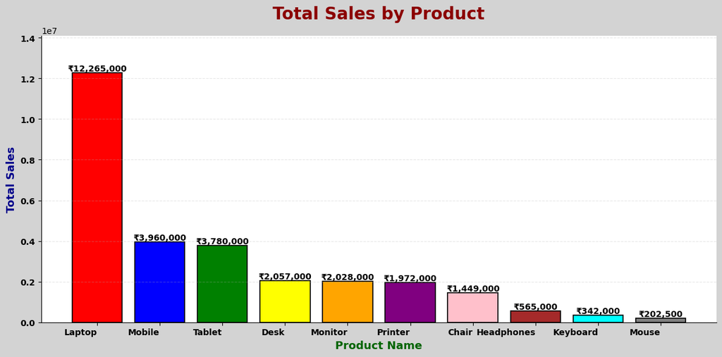

```python
plt.figure(figsize=(12, 6), facecolor="lightgray")
bars = plt.bar(
    product_sales["Product"],
    product_sales["Sales"],
    color=["red", "blue", "green", "yellow", "orange",
           "purple", "pink", "brown", "cyan", "gray"],
    edgecolor="black",
    linewidth=1.2
)

# Chart Title
plt.title(
    "Total Sales by Product",
    fontsize=20,
    fontweight="bold",
    color="darkred",
    pad=20
)

# x-Axis Labels
plt.xlabel(
    "Product Name",
    fontsize=13,
    fontweight="bold",
    color="darkgreen"
)

# y-Axis Labels
plt.ylabel(
    "Total Sales",
    fontsize=13,
    fontweight="bold",
    color="darkblue"
)

# Product names
plt.xticks(
    rotation=0,
    ha="right",
    fontsize=10,
    fontweight="bold"
)

# Total Sales
plt.yticks(
    fontsize=10,
    fontweight="bold"
)

# Background
plt.gca().set_facecolor("white")

# Light grid
plt.grid(
    axis="y",
    linestyle="--",
    alpha=0.3
)

# Sales value bar ke upar
for bar in bars:
    value = bar.get_height()
    plt.text(
        bar.get_x() + bar.get_width() / 2,
        value,
        f"₹{value:,.0f}",
        ha="center",
        va="bottom",
        fontsize=10,
        fontweight="bold"
    )

# Y-axis me thoda extra space
plt.ylim(
    0,
    product_sales["Sales"].max() * 1.15
)

# Layout adjust
plt.tight_layout()


# Border/spines ko clean kiya
plt.gca().spines["top"].set_visible(False)
plt.gca().spines["right"].set_visible(False)

plt.show()
```

Q32. Create a Bar Chart showing category-wise Sales.

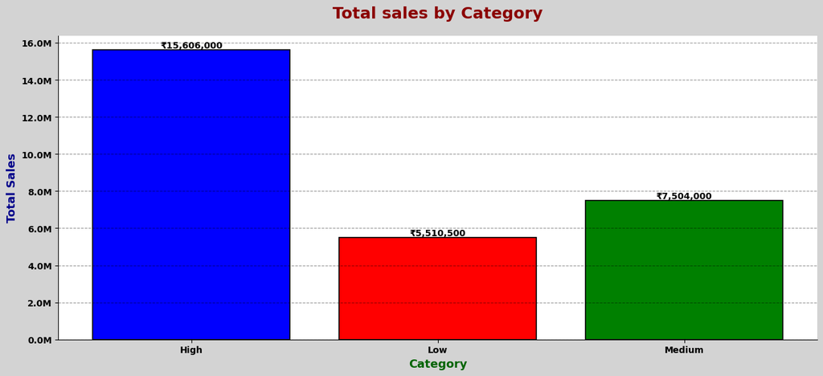

```python
plt.figure(figsize=(13, 6), facecolor="lightgray")
bar = plt.bar(
    Total_Category_a.index,
    Total_Category_a.values,
    color = ["blue", "red", "green", "yellow"],
    edgecolor="black",
    linewidth=1.2
)
plt.title("Total sales by Category",
    fontsize=18,
    fontweight="bold",
    color="darkred",
    pad=20
)

plt.xlabel("Category",
    fontsize=13,
    fontweight="bold",
    color= "darkgreen"
)
plt.ylabel("Total Sales",
    fontsize=13,
    fontweight="bold",
    color= "darkblue"
)

# Product names
plt.xticks(
    rotation=0,
    ha="center",
    fontsize=10,
    fontweight="bold"
)

# Total_sales
plt.yticks(
    fontsize=10,
    fontweight="bold"
)

plt.grid(
    axis="y",
    linestyle="--",
    alpha=0.4,
    color="black"
)
# Y-axis ko readable format mein
plt.gca().yaxis.set_major_formatter(
    FuncFormatter(lambda x, pos: f"{x/1e6:.1f}M")
)

# Sales value bar ke upar
for b in bar:
    height = b.get_height()
    plt.text(
        b.get_x() + b.get_width() / 2,
        height,
        f"₹{height:,.0f}",
        ha="center",
        va="bottom",
        fontsize=10,
        fontweight="bold"
    )

# Layout adjust
plt.tight_layout()

# Border/spines ko clean kiya
plt.gca().spines["top"].set_visible(False)
plt.gca().spines["right"].set_visible(False)

plt.show()
```

Q33. Create a Bar Chart showing city-wise Sales.

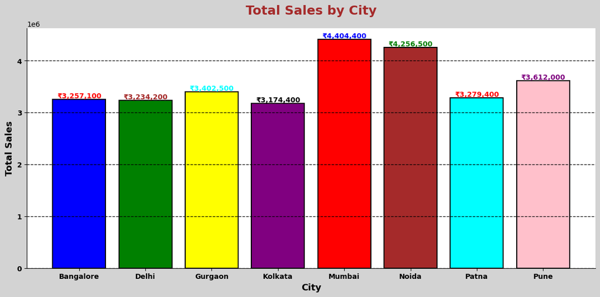

```python
plt.figure(figsize=(12, 6), facecolor="lightgray")
bar = plt.bar(
    total_city.index,
    total_city.values,
    color=["blue", "green", "yellow", "purple",
            "red", "brown", "cyan", "pink",],
    edgecolor="black",
    linewidth=1.5
)

plt.title(
    "Total Sales by City",
    fontsize=18,
    fontweight="bold",
    color="brown",
    pad=20
)

plt.xlabel(
    "City",
    fontsize=13,
    fontweight="bold",
    color="black"
)

plt.ylabel(
    "Total Sales",
    fontsize=13,
    fontweight="bold",
    color="black"
)

plt.xticks(
    rotation=0,
    ha="center",
    fontsize=10,
    fontweight="bold"
)

plt.yticks(
    fontsize=10,
    fontweight="bold"
)

plt.grid(
    axis="y",
    linestyle="--",
    color="black",
    alpha=0.9,
    linewidth=1
)

text_colors = ["red", "brown", "cyan", "black",
            "blue", "green", "red", "purple"]
for i, a in enumerate(bar):
    value = a.get_height()
    plt.text(
        a.get_x() + a.get_width() / 2,
        value,
        f"₹{value:,.0f}",
        ha="center",
        va="bottom",
        fontsize=10,
        fontweight="bold",
        color = text_colors[i]
    )

plt.gca().spines["top"].set_visible(False)
plt.gca().spines["right"].set_visible(False)

plt.tight_layout()

plt.show()
```

Q34. Create a Bar Chart showing region-wise Sales.

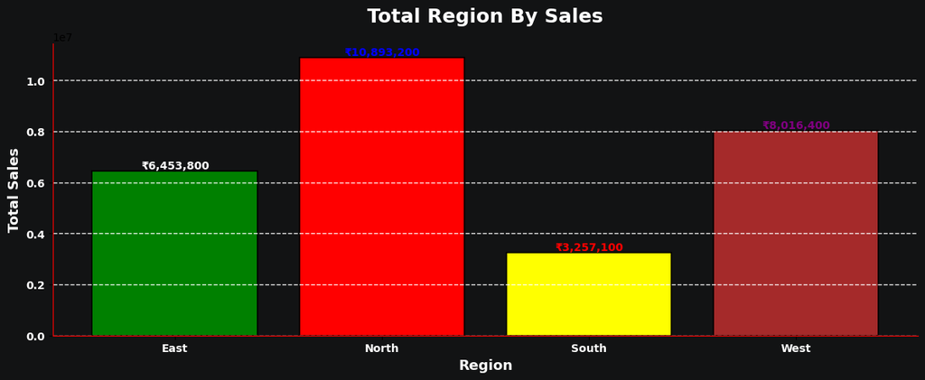

```python
Regin_By_Sales

plt.figure(figsize=(12, 5),
    facecolor="#121314"
)

bar = plt.bar(
    Regin_By_Sales.index,
    Regin_By_Sales.values,
    color=["green", "red", "yellow", "brown"],
    edgecolor="black",
    linewidth=1.2
)

plt.gca().set_facecolor("#121314")

plt.title(
    "Total Region By Sales",
    fontsize=18,
    fontweight="bold",
    color="white",
    pad=20
)

plt.xlabel(
    "Region",
    fontsize=13,
    fontweight="bold",
    color="white"
)

plt.ylabel(
    "Total Sales",
    fontsize=13,
    fontweight="bold",
    color="white"
)

plt.xticks(
    rotation=0,
    ha="center",
    fontsize=10,
    fontweight="bold",
    color="white"
)

plt.yticks(
    fontsize=10,
    fontweight="bold",
    color="white"
)

plt.grid(
    axis="y",
    linestyle="--",
    color="white",
    alpha=0.9,
    linewidth=1
)

text_colors = ["white", "blue", "red", "purple"]
for p,c in enumerate(bar):
    value = c.get_height()
    plt.text(
        c.get_x() + c.get_width() / 2,
        value,
        f"₹{value:,.0f}",
        ha="center",
        va="bottom",
        fontsize=10,
        fontweight="bold",
        color=text_colors[p]
    )

plt.gca().spines["bottom"].set_color("red")
plt.gca().spines["left"].set_color("red")
plt.gca().spines["top"].set_visible(False)
plt.gca().spines["right"].set_visible(False)

plt.tight_layout()

plt.show()
```

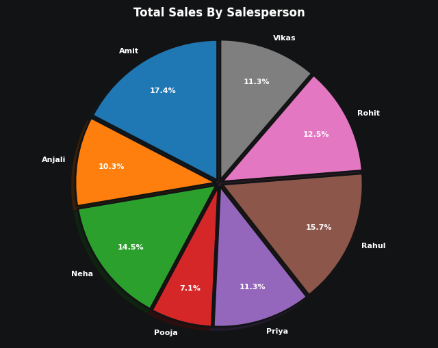

```python
plt.figure(figsize=(8, 6), facecolor="#121314")

bar = plt.pie(
    Total_Salesperson.values,
    labels = Total_Salesperson.index,
    autopct="%1.1f%%",
    startangle=90,
    textprops={
        "fontsize": 8,
        "fontweight": "bold",
        "color": "white"
    },
    explode=[0.03] * len(Total_Salesperson),
    shadow=True,             # shadow
    wedgeprops={
        "edgecolor": "#121314",
        "linewidth": 2
    },
    pctdistance=0.75,
    labeldistance=1.08,
    radius=1.2
)

plt.title(
    "Total Sales By Salesperson",
    color="White",
    fontweight="bold",
    fontsize=12,
    pad=10
)

plt.axis("equal")

plt.show()
```

Q36. Create a Pie Chart showing the number of Orders by Payment Mode.

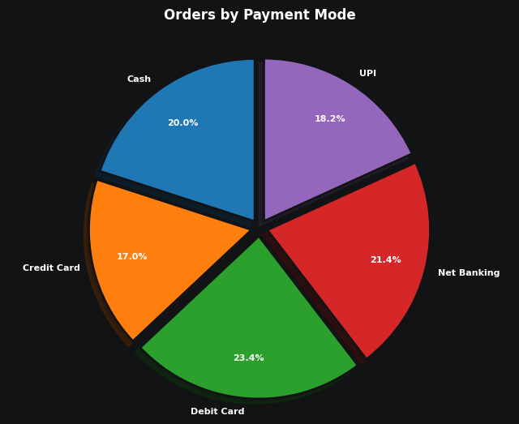

```python
plt.figure(figsize=(8, 6), facecolor="#121314")

plt.pie(
    Orders_By_Payment.values,
    labels=Orders_By_Payment.index,
    autopct="%1.1f%%",       # percentage
    startangle=90,           # chart rotation
    explode=[0.05] * len(Orders_By_Payment),  # slices thoda gap
    shadow=True,             # shadow
    wedgeprops={
        "edgecolor": "#121314",
        "linewidth": 2
    },
    pctdistance=0.75,
    labeldistance=1.08,
    textprops={
        "fontsize": 8,
        "fontweight": "bold",
        "color": "white"
    }
)

plt.title(
    "Orders by Payment Mode",
    fontsize=12,
    fontweight="bold",
    color="white",
    pad=20
)

plt.axis("equal")

plt.show()
```

Q37. Create a Pie Chart showing the percentage of Sales by Category.

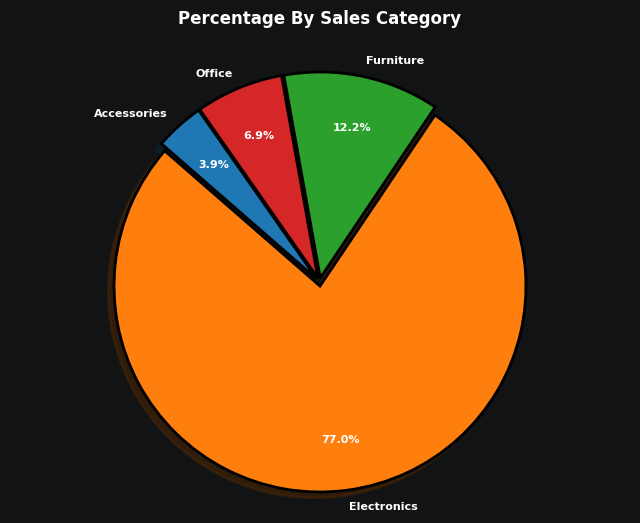

```python
plt.figure(figsize=(8,6), facecolor="#121314")
bar = plt.pie(
    Total_Category.values,
    labels=Total_Category.index,
    autopct="%1.1f%%",
    startangle=125,
    explode=[0.02] * len(Total_Category),
    shadow=True,
    wedgeprops={
        "edgecolor": "#000000",
        "linewidth": 2
    },
    pctdistance=0.75,
    labeldistance=1.08,
    textprops={
        "fontsize": 8,
        "fontweight": "bold",
        "color": "white"
    }
)

plt.title(
    "Percentage By Sales Category",
    fontsize=12,
    fontweight="bold",
    color="white",
    pad=20
)

plt.axis("equal")

plt.show()
```

Q38. Create a Line Chart showing month-wise Sales.

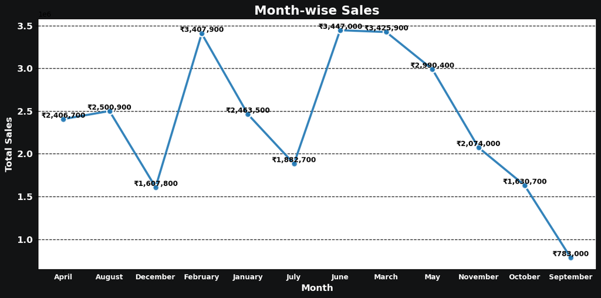

```python
plt.figure(
    figsize=(12, 6),
    facecolor="#121314",
    edgecolor="#DFE6EC"
)

plt.plot(
    Month_sales.index,
    Month_sales.values,
    marker="o",
    markersize=9,
    markeredgecolor="white",
    markeredgewidth=2,
    linewidth=3,
    linestyle="-",
    alpha=0.9
)

plt.title(
    "Month-wise Sales",
    fontsize=18,
    fontweight="bold",
    color="white"
)

plt.xlabel(
    "Month",
    fontsize=13,
    fontweight="bold",
    color="white"
)

plt.ylabel(
    "Total Sales",
    fontsize=13,
    fontweight="bold",
    color="white"
)

plt.xticks(
    rotation=0,
    ha="center",
    fontsize=10,
    fontweight="bold",
    color="white"
)

plt.yticks(
    fontsize=13,
    fontweight="bold",
    color="white"
)

plt.grid(
    axis="y",
    linestyle="--",
    color="black",
    alpha=0.9,
    linewidth=1
)

for x, y in zip(Month_sales.index, Month_sales.values):
    plt.text(
        x,
        y,
        f"₹{y:,.0f}",
        ha="center",
        va="bottom",
        fontsize=10,
        fontweight="bold",
        color="black"
    )

plt.tight_layout()

plt.show()
```

Q41. Create a Scatter Plot showing the relationship between UnitPrice and Sales.

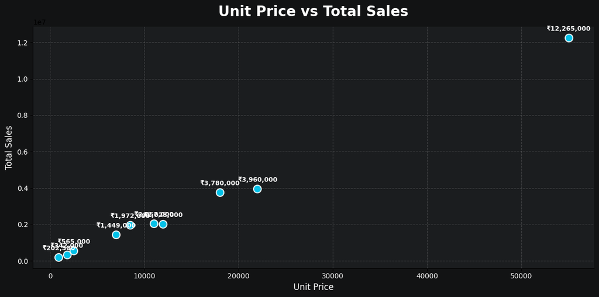

```python
plt.figure(
    figsize=(12, 6),
    facecolor="#121314"
)

ax = plt.gca()
ax.set_facecolor("#1B1D1F")

plt.scatter(
    UnitPrice_Sales.index,
    UnitPrice_Sales.values,
    s=120,
    color="#00D4FF",
    edgecolor="white",
    linewidth=1.5,
    alpha=0.9
)

# Data labels
for x, y in zip(UnitPrice_Sales.index, UnitPrice_Sales.values):
    plt.annotate(
        f"₹{y:,.0f}",
        (x, y),
        xytext=(0, 10),
        textcoords="offset points",
        ha="center",
        fontsize=9,
        color="white",
        fontweight="bold"
    )

plt.title(
    "Unit Price vs Total Sales",
    fontsize=20,
    fontweight="bold",
    color="white",
    pad=15
)

plt.xlabel(
    "Unit Price",
    fontsize=12,
    color="white"
)

plt.ylabel(
    "Total Sales",
    fontsize=12,
    color="white"
)

# Format axes
plt.xticks(color="white")
plt.yticks(color="white")

# Grid
plt.grid(
    True,
    linestyle="--",
    alpha=0.25
)

# Remove top/right border
ax.spines["top"].set_visible(False)
ax.spines["right"].set_visible(False)

plt.tight_layout()
plt.show()
```